# NYPD Shooting Incident Data (Historic)

C. Magganas

2022-04-22

The purpose of this report is to analyze the [NYPD Shooting Incident Data](https://catalog.data.gov/dataset/nypd-shooting-incident-data-historic) , a list of every shooting incident that occurred in NYC going back to 2006 through the end of the previous calendar year. Using the toolkit available to us in R, I intend to explore the dataset, ask questions and make recommendations based on any findings.

### Load packages

```r
library('tidyverse')
library('sf')
library('data.table')
```

## Tidy and Transform Your Data

### Load csv files + datatype changes

```r
# Load csv from URL
NYPD_Shooting_Incident_Data <- read_csv(
  "https://data.cityofnewyork.us/api/views/833y-fsy8/rows.csv")
# Change types and remove redundant rows
NYPD_Shooting_Incident_Data <- NYPD_Shooting_Incident_Data %>%
  mutate(
    OCCUR_DATE = as.Date(OCCUR_DATE, "%m/%d/%Y"),
    PRECINCT = as.character(PRECINCT),
    JURISDICTION_CODE = as.character(JURISDICTION_CODE)) %>%
  select(-c(X_COORD_CD, Y_COORD_CD))
head(NYPD_Shooting_Incident_Data)
```

| INCIDENT_KEY | OCCUR_DATE | OCCUR_TIME | BORO | PRECINCT | JURISDICTION_CODE | LOCATION_DESC | STATISTICAL_MURDER_FLAG | PERP_AGE_GROUP | PERP_SEX | PERP_RACE | VIC_AGE_GROUP | VIC_SEX | VIC_RACE | Latitude | Longitude | Lon_Lat |
| --- | --- | --- | --- | --- | --- | --- | --- | --- | --- | --- | --- | --- | --- | --- | --- | --- |
| 24050482 | 2006-08-27 | 05:35:00 | BRONX | 52 | 0 | NA | TRUE | NA | NA | NA | 25-44 | F | BLACK HISPANIC | 40.86906 | -73.87963 | POINT (-73.87963173099996 40.86905819000003) |
| 77673979 | 2011-03-11 | 12:03:00 | QUEENS | 106 | 0 | NA | FALSE | NA | NA | NA | 65+ | M | WHITE | 40.67737 | -73.84392 | POINT (-73.84392019199998 40.677366895000034) |
| 203350417 | 2019-10-06 | 01:09:00 | BROOKLYN | 77 | 0 | NA | FALSE | NA | NA | NA | 18-24 | F | BLACK | 40.67489 | -73.96008 | POINT (-73.96007501899999 40.674885741000026) |
| 80584527 | 2011-09-04 | 03:35:00 | BRONX | 40 | 0 | NA | FALSE | NA | NA | NA | <18 | M | BLACK | 40.80880 | -73.91618 | POINT (-73.91618413199996 40.80879780500004) |
| 90843766 | 2013-05-27 | 21:16:00 | QUEENS | 100 | 0 | NA | FALSE | NA | NA | NA | 18-24 | M | BLACK | 40.59780 | -73.79469 | POINT (-73.79468553799995 40.597796249000055) |
| 92393427 | 2013-09-01 | 04:17:00 | BROOKLYN | 67 | 0 | NA | FALSE | NA | NA | NA | <18 | M | BLACK | 40.63359 | -73.93715 | POINT (-73.93715330699996 40.63358818100005) |

### Data Summary

```r
summary(NYPD_Shooting_Incident_Data)
```

```
##   INCIDENT_KEY         OCCUR_DATE          OCCUR_TIME           BORO
##  Min.   :  9953245   Min.   :2006-01-01   Length:23585      Length:23585
##  1st Qu.: 55322804   1st Qu.:2008-12-31   Class1:hms        Class :character
##  Median : 83435362   Median :2012-02-27   Class2:difftime   Mode  :character
##  Mean   :102280741   Mean   :2012-10-05   Mode  :numeric
##  3rd Qu.:150911774   3rd Qu.:2016-03-02
##  Max.   :230611229   Max.   :2020-12-31
##    PRECINCT         JURISDICTION_CODE  LOCATION_DESC
##  Length:23585       Length:23585       Length:23585
##  Class :character   Class :character   Class :character
##  Mode  :character   Mode  :character   Mode  :character
##
##
##
##  STATISTICAL_MURDER_FLAG PERP_AGE_GROUP       PERP_SEX
##  Mode :logical           Length:23585       Length:23585
##  FALSE:19085             Class :character   Class :character
##  TRUE :4500              Mode  :character   Mode  :character
##
##
##
##   PERP_RACE         VIC_AGE_GROUP        VIC_SEX            VIC_RACE
##  Length:23585       Length:23585       Length:23585       Length:23585
##  Class :character   Class :character   Class :character   Class :character
##  Mode  :character   Mode  :character   Mode  :character   Mode  :character
##
##
##
##     Latitude       Longitude        Lon_Lat
##  Min.   :40.51   Min.   :-74.25   Length:23585
##  1st Qu.:40.67   1st Qu.:-73.94   Class :character
##  Median :40.70   Median :-73.92   Mode  :character
##  Mean   :40.74   Mean   :-73.91
##  3rd Qu.:40.82   3rd Qu.:-73.88
##  Max.   :40.91   Max.   :-73.70
```

### Group By Borough, Year/Hour

```r
Shootings_by_Boro_per_year <- NYPD_Shooting_Incident_Data %>%
  group_by(BORO, YEAR = format(OCCUR_DATE, "%Y")) %>%
  summarise(INCIDENTS = n())
Shootings_by_Boro_per_hour <- NYPD_Shooting_Incident_Data %>%
  group_by(BORO, HOUR = as.POSIXlt(OCCUR_TIME)$hour) %>%
  summarise(INCIDENTS = n())
```

## Visualizations and Analysis

### Map of NYC shootings

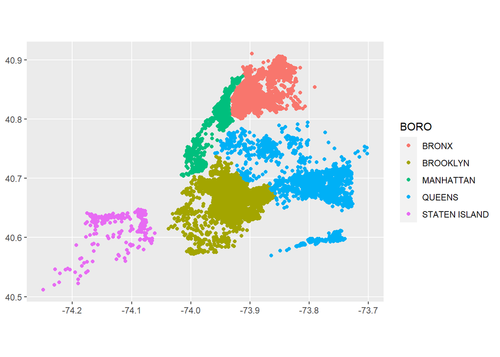

```r
ggplot(st_as_sf(NYPD_Shooting_Incident_Data,
                coords = c("Longitude", "Latitude"))) +
  geom_sf(aes(color = BORO))
```

### Plot shootings by Borough per Year

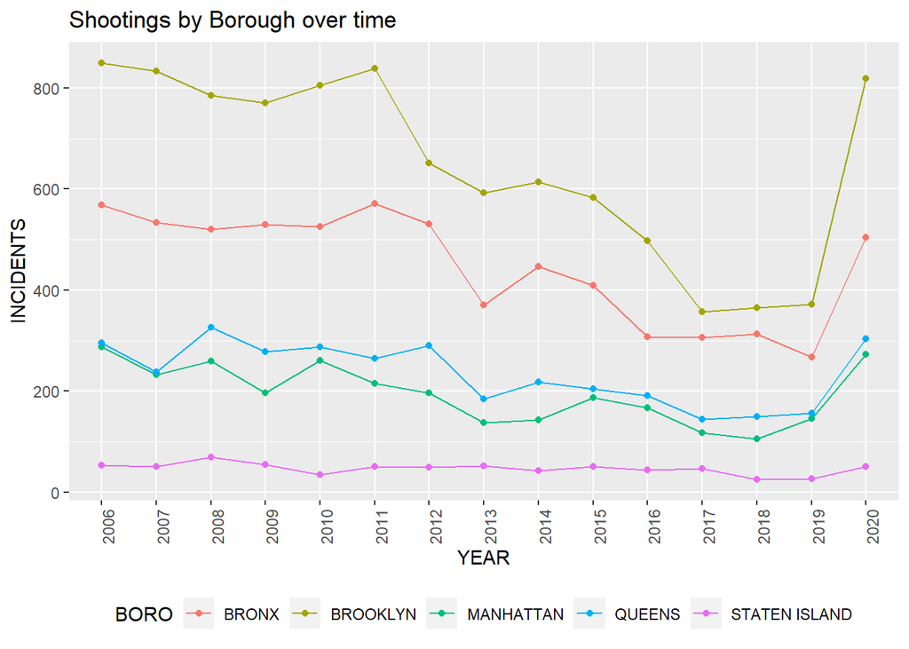

```r
Shootings_by_Boro_per_year  %>%
  ggplot(aes(x=YEAR, y=INCIDENTS, group = BORO)) +
  geom_line(aes(color = BORO)) +
  geom_point(aes(color = BORO)) +
  theme(legend.position = "bottom",
        axis.text.x = element_text(angle = 90)) +
  labs(title = "Shootings by Borough over time")
```

It seems like total shootings have gone down over time, with the exception of 2020. This is likely due to COVID-19 lock-downs causing social distress and animosity. An initial guess would be that shootings and human overall well-being are related.

### Plot shootings by Borough by Hour

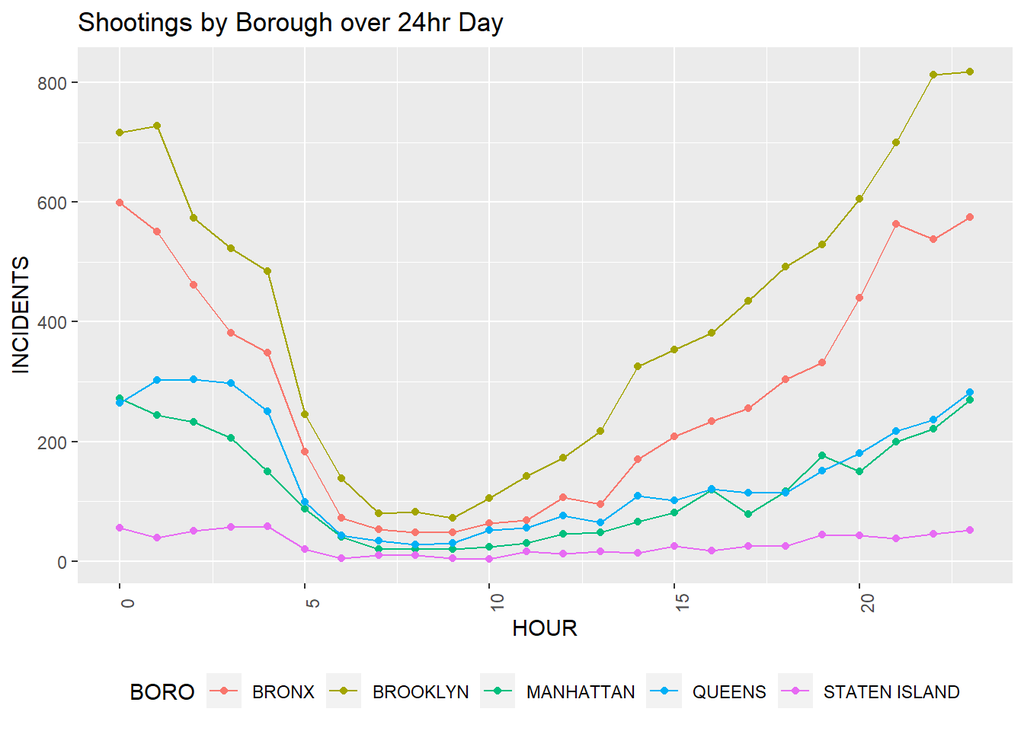

```r
Shootings_by_Boro_per_hour  %>%
  ggplot(aes(x=HOUR, y=INCIDENTS, group = BORO)) +
  geom_line(aes(color = BORO)) +
  geom_point(aes(color = BORO)) +
  theme(legend.position = "bottom",
        axis.text.x = element_text(angle = 90)) +
  labs(title = "Shootings by Borough over 24hr Day")
```

This makes total sense, because people are asleep and at home in the mornings (less shootings). As the temperature rises, parties start and the liquor and substances flow, the number of shootings increase into the late night hours. With additional data and/or analysis we would likely see temperature, social gatherings and other factors relating to these trends. But that’s just my bias…

### Model likelihood incident resulted in Murder

#### (by TimeOfDay and DayOfWeek)

```r
Mur <- NYPD_Shooting_Incident_Data$STATISTICAL_MURDER_FLAG
DoW <- weekdays(NYPD_Shooting_Incident_Data$OCCUR_DATE)
ToD <- as.character(as.POSIXlt(NYPD_Shooting_Incident_Data$OCCUR_TIME)$hour)
murder_table <- data.table(Mur,DoW,ToD)
fit <- lm(Mur ~ DoW + ToD, data=murder_table)
summary(fit)
```

```
##
## Call:
## lm(formula = Mur ~ DoW + ToD, data = murder_table)
##
## Residuals:
##     Min      1Q  Median      3Q     Max
## -0.3524 -0.1973 -0.1755 -0.1543  0.8732
##
## Coefficients:
##               Estimate Std. Error t value Pr(>|t|)
## (Intercept)   0.181686   0.011292  16.089  < 2e-16 ***
## DoWMonday    -0.006189   0.009811  -0.631 0.528151
## DoWSaturday  -0.025732   0.009274  -2.775 0.005531 **
## DoWSunday    -0.016675   0.009212  -1.810 0.070291 .
## DoWThursday  -0.005122   0.010497  -0.488 0.625591
## DoWTuesday   -0.008941   0.010322  -0.866 0.386394
## DoWWednesday  0.001756   0.010465   0.168 0.866751
## ToD1          0.006007   0.012768   0.471 0.637995
## ToD10         0.064443   0.026485   2.433 0.014973 *
## ToD11         0.083915   0.023868   3.516 0.000439 ***
## ToD12         0.065592   0.021264   3.085 0.002040 **
## ToD13         0.048481   0.020732   2.338 0.019370 *
## ToD14         0.033869   0.017499   1.935 0.052948 .
## ToD15         0.002443   0.016769   0.146 0.884175
## ToD16        -0.029142   0.016051  -1.816 0.069450 .
## ToD17         0.032277   0.015852   2.036 0.041742 *
## ToD18         0.057492   0.015095   3.809 0.000140 ***
## ToD19         0.013569   0.014374   0.944 0.345169
## ToD2          0.007835   0.013247   0.591 0.554218
## ToD20        -0.001832   0.013794  -0.133 0.894375
## ToD21         0.015925   0.013089   1.217 0.223714
## ToD22         0.028888   0.012851   2.248 0.024595 *
## ToD23        -0.013166   0.012592  -1.046 0.295760
## ToD3          0.010073   0.013646   0.738 0.460442
## ToD4          0.029037   0.014152   2.052 0.040201 *
## ToD5          0.085046   0.017985   4.729 2.27e-06 ***
## ToD6          0.065340   0.024316   2.687 0.007212 **
## ToD7          0.168935   0.029266   5.772 7.91e-09 ***
## ToD8          0.095652   0.029837   3.206 0.001348 **
## ToD9          0.080067   0.030837   2.596 0.009425 **
## ---
## Signif. codes:  0 '***' 0.001 '**' 0.01 '*' 0.05 '.' 0.1 ' ' 1
##
## Residual standard error: 0.3919 on 23555 degrees of freedom
## Multiple R-squared:  0.006387,   Adjusted R-squared:  0.005164
## F-statistic: 5.221 on 29 and 23555 DF,  p-value: < 2.2e-16
```

```r
murder_table <- murder_table %>% mutate(pred = predict(fit))
murder_pred <- murder_table %>%
  group_by(DoW,ToD) %>% summarise(avg_pred_mur = mean(pred), incidents = n()) %>% arrange(desc(avg_pred_mur))
murder_pred
```

| DoW | ToD | avg_pred_mur | incidents |
| --- | --- | --- | --- |
| Wednesday | 7 | 0.3523762 | 18 |
| Friday | 7 | 0.3506203 | 17 |
| Thursday | 7 | 0.3454982 | 17 |
| Monday | 7 | 0.3444313 | 32 |
| Tuesday | 7 | 0.3416798 | 18 |
| Sunday | 7 | 0.3339454 | 51 |
| Saturday | 7 | 0.3248879 | 45 |
| Wednesday | 8 | 0.2790941 | 21 |
| Friday | 8 | 0.2773383 | 30 |
| Thursday | 8 | 0.2722162 | 24 |

[output cut: 158 more lines]

## Bias Identification

As we look at this data, we initially look to confirm our own biases to quickly satisfy our curiosity for understanding this data and any solution we might come up with. It is important to keep this in consideration and ask ourselves what questions and/or alternative perspectives we can use to better understand what is happening. Additionally, there might be some bias in the data itself. The NYPD is not themselves unbiased and may have some incentive to favorable outcomes. These are only reported shootings and may not depict a population wide representation. Some factors include, who reports a shooting, police presence in these neighborhoods, etc.

## Closing Thoughts

This has been an informative exploration. Further analysis and additional data is required to make any real recommendations. In the future, I would combine different datasets together and involve experts on the subject matter before prescribing any plan of action.